# Pracitical Machine Learning - Coursera Course Project

## Synopsis

The task of this project is to create a learning algorithm that is trained on the `traindata` and gets then used on the `testdata` to predict `classe`. `classe` is a factor variable that indicates what type of exercise was done by the participants. There are five levels available each describing a different way of barbell lifting performance.

## Loading Data

```r
url <- "https://d396qusza40orc.cloudfront.net/predmachlearn/pml-training.csv"
download.file(url, destfile = "traindata.csv", method = "curl")

url <- "https://d396qusza40orc.cloudfront.net/predmachlearn/pml-testing.csv"
download.file(url, destfile = "testdata.csv", method = "curl")
```

```r
traindata <- read.csv("traindata.csv")
traindata$X <- NULL
testdata <- read.csv("testdata.csv")
testdata$X <- NULL
```

Removing column `X` is done because by reading the csv files this column `X` with only the row numbers in it was created.

## Preprocessing Data

Checking for NA proportion in `traindata`.

```r
mean(is.na(traindata))
```

```
## [1] 0.4127
```

0.41 is very high proportion of NA.  
To reduce the proportion of NAs in the training set checking if there are columns in the `testdata` that are completely filled with NAs because when later using the model for prediction on the test set the model cannot predict for variables with NA so `traindata` columns can be reduced by these fully missing columns in `testdata`. As there are 159 columns in the `testdata` just the first 20 results for complete NA columns in `testdata` will be shown below.

```r
head(apply(is.na(testdata), 2, all), 20)
```

```
##            user_name raw_timestamp_part_1 raw_timestamp_part_2
##                FALSE                FALSE                FALSE
##       cvtd_timestamp           new_window           num_window
##                FALSE                FALSE                FALSE
##            roll_belt           pitch_belt             yaw_belt
##                FALSE                FALSE                FALSE
##     total_accel_belt   kurtosis_roll_belt  kurtosis_picth_belt
##                FALSE                 TRUE                 TRUE
##    kurtosis_yaw_belt   skewness_roll_belt skewness_roll_belt.1
##                 TRUE                 TRUE                 TRUE
##    skewness_yaw_belt        max_roll_belt       max_picth_belt
##                 TRUE                 TRUE                 TRUE
##         max_yaw_belt        min_roll_belt
##                 TRUE                 TRUE
```

**TRUE** says there are columns in `testdata` that constist completely of NAs.  
Next the columns that are completely NA in `testdata` get removed as well in `traindata` as in `testdata`. Since the apply() function for complete NA columns gives back **TRUE** if there are only NAs in the concerned columns the columns that give back **FALSE** have to be selected.

```r
traindata <- traindata[, apply(is.na(testdata), 2, all) == FALSE]
testdata <- testdata[, apply(is.na(testdata), 2, all) == FALSE]
```

From 159 columns before there are now just 59 columns left.  
Checking both data sets for NA proportion.

```r
c(mean(is.na(traindata)), mean(is.na(testdata)))
```

```
## [1] 0 0
```

In both data sets are no NAs left.  
Short overview of the data in `traindata`.

```r
str(traindata)
```

```
## 'data.frame':    19622 obs. of  59 variables:
##  $ user_name           : Factor w/ 6 levels "adelmo","carlitos",..: 2 2 2 2 2 2 2 2 2 2 ...
##  $ raw_timestamp_part_1: int  1323084231 1323084231 1323084231 1323084232 1323084232 1323084232 1323084232 1323084232 1323084232 1323084232 ...
##  $ raw_timestamp_part_2: int  788290 808298 820366 120339 196328 304277 368296 440390 484323 484434 ...
##  $ cvtd_timestamp      : Factor w/ 20 levels "02/12/2011 13:32",..: 9 9 9 9 9 9 9 9 9 9 ...
##  $ new_window          : Factor w/ 2 levels "no","yes": 1 1 1 1 1 1 1 1 1 1 ...
##  $ num_window          : int  11 11 11 12 12 12 12 12 12 12 ...
##  $ roll_belt           : num  1.41 1.41 1.42 1.48 1.48 1.45 1.42 1.42 1.43 1.45 ...
##  $ pitch_belt          : num  8.07 8.07 8.07 8.05 8.07 8.06 8.09 8.13 8.16 8.17 ...
##  $ yaw_belt            : num  -94.4 -94.4 -94.4 -94.4 -94.4 -94.4 -94.4 -94.4 -94.4 -94.4 ...
##  $ total_accel_belt    : int  3 3 3 3 3 3 3 3 3 3 ...
##  $ gyros_belt_x        : num  0 0.02 0 0.02 0.02 0.02 0.02 0.02 0.02 0.03 ...
##  $ gyros_belt_y        : num  0 0 0 0 0.02 0 0 0 0 0 ...
##  $ gyros_belt_z        : num  -0.02 -0.02 -0.02 -0.03 -0.02 -0.02 -0.02 -0.02 -0.02 0 ...
##  $ accel_belt_x        : int  -21 -22 -20 -22 -21 -21 -22 -22 -20 -21 ...
```

[output cut: 45 more lines]

The only structural difference between `traindata` and `testdata` is the last column.

```r
tail(names(traindata), 4); tail(names(testdata), 4)
```

```
## [1] "magnet_forearm_x" "magnet_forearm_y" "magnet_forearm_z"
## [4] "classe"
```

```
## [1] "magnet_forearm_x" "magnet_forearm_y" "magnet_forearm_z"
## [4] "problem_id"
```

As the data are preprocessed now and there are no NAs left, next model training will begin.

## Training Model

#### Fitting random Forest model

At first training a random forest model with `caret` package and cross-validation. The train function from `caret` then by default uses 10 fold cv dividing the `traindata` into ten parts, training random forest on 9/10 of the divided training data and predicting the model on the left parts. At the end the average of the different results is taken and the best model gets selected. (linear and binomial models are not possible as `class` is 5 level factor variable so it is a classification problem with more than 0 and 1 levels)

```r
suppressMessages(library(caret))
modelFit1 <- train(classe ~ ., data = traindata, method = "rf", trControl = trainControl(method = "cv"))
modelFit1
```

```
## Random Forest
##
## 19622 samples
##    58 predictor
##     5 classes: 'A', 'B', 'C', 'D', 'E'
##
## No pre-processing
## Resampling: Cross-Validated (10 fold)
##
## Summary of sample sizes: 17660, 17660, 17660, 17660, 17658, 17659, ...
##
## Resampling results across tuning parameters:
##
##   mtry  Accuracy  Kappa  Accuracy SD  Kappa SD
##    2    1         1      3e-03        4e-03
##   41    1         1      3e-04        4e-04
##   80    1         1      6e-04        7e-04
##
## Accuracy was used to select the optimal model using  the largest value.
## The final value used for the model was mtry = 41.
```

Assuming out-of-sample error by using the 10 folds from cross-validation from `modelFit1`:

```r
modelFit1$resample
```

```
##    Accuracy  Kappa Resample
## 1    0.9995 0.9994   Fold02
## 2    1.0000 1.0000   Fold01
## 3    0.9995 0.9994   Fold04
## 4    0.9990 0.9987   Fold03
## 5    0.9995 0.9994   Fold06
## 6    1.0000 1.0000   Fold05
## 7    0.9995 0.9994   Fold08
## 8    1.0000 1.0000   Fold07
## 9    0.9995 0.9994   Fold10
## 10   0.9995 0.9994   Fold09
```

```r
min(modelFit1$resample$Accuracy) # expected out-of-sample error
```

```
## [1] 0.999
```

As the fitted model on the training data will always be better then the predicted model this leads to the assumption that the accuracy of the prediction will be more about the minimum accuracy of the 10 fold accuracy results so 0.999.  
Predicting with random forest model:

```r
pred1 <- predict(modelFit1, newdata = testdata)
pred1
```

```
##  [1] B A B A A E D B A A B C B A E E A B B B
## Levels: A B C D E
```

Entering the results from random forest prediction `pred1` into the coursera project submission gave back 20 of 20 so 100% accuracy. Deriving from this pred1 will be used as the test data results further on.

#### Fitting rpart model

Fitting a rpart model with pca preprocessing to reduce the dimensions a little bit.

```r
suppressMessages(library(caret))
suppressMessages(library(rattle))
modelFit2 <- train(classe ~., data = traindata, method = "rpart", trControl = trainControl(method = "cv"), preProcess = "pca")
modelFit2
```

```
## CART
##
## 19622 samples
##    58 predictor
##     5 classes: 'A', 'B', 'C', 'D', 'E'
##
## Pre-processing: principal component signal extraction, scaled, centered
## Resampling: Cross-Validated (10 fold)
##
## Summary of sample sizes: 17661, 17660, 17659, 17661, 17660, 17658, ...
##
## Resampling results across tuning parameters:
##
##   cp    Accuracy  Kappa  Accuracy SD  Kappa SD
##   0.04  0.4       0.3    3e-02        0.04
##   0.05  0.4       0.2    3e-02        0.04
##   0.12  0.3       0.0    1e-04        0.00
##
## Accuracy was used to select the optimal model using  the largest value.
## The final value used for the model was cp = 0.04024.
```

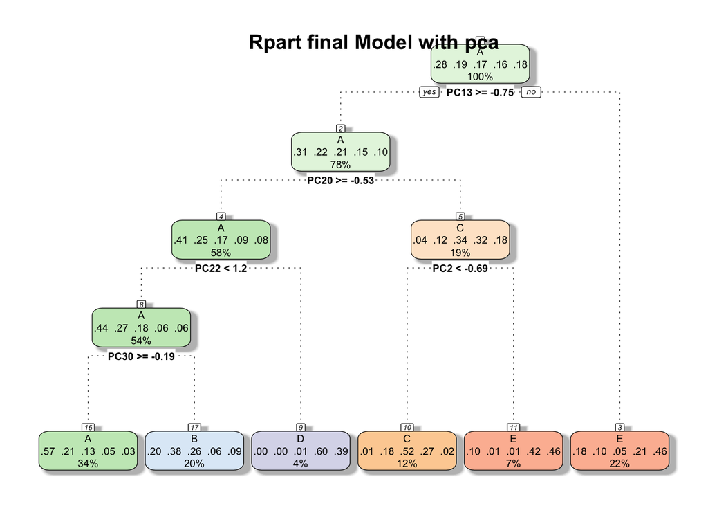

```r
fancyRpartPlot(modelFit2$finalModel, main = "Rpart final Model with pca", sub = NULL)
```

Assuming out-of-sample error again:

```r
modelFit2$resample
```

```
##    Accuracy  Kappa Resample
## 1    0.4450 0.2747   Fold02
## 2    0.5110 0.3752   Fold01
## 3    0.4340 0.2476   Fold03
## 4    0.4353 0.2581   Fold06
## 5    0.4225 0.2391   Fold05
## 6    0.4748 0.3291   Fold04
## 7    0.4401 0.2652   Fold07
## 8    0.4348 0.2560   Fold10
## 9    0.4610 0.3178   Fold09
## 10   0.4309 0.2493   Fold08
```

```r
min(modelFit2$resample$Accuracy) # expected out-of-sample error
```

```
## [1] 0.4225
```

As before the out-of-sample respectively test data accuracy is assumed to be worse than the accuracy of the trainin data so assuming the test data accuracy to be about 0.423.  
Making prediction with the rpart model and comparing the prediction results with the random forest predictions.

```r
suppressMessages(library(caret))
pred2 <- predict(modelFit2, newdata = testdata)
confusionMatrix(pred2, pred1)
```

```
## Confusion Matrix and Statistics
##
##           Reference
## Prediction A B C D E
##          A 5 2 0 0 0
##          B 1 5 1 0 0
##          C 0 0 0 0 0
##          D 0 0 0 1 0
##          E 1 1 0 0 3
##
## Overall Statistics
##
##                Accuracy : 0.7
##                  95% CI : (0.457, 0.881)
##     No Information Rate : 0.4
##     P-Value [Acc > NIR] : 0.00647
##
##                   Kappa : 0.57
##  Mcnemar's Test P-Value : NA
##
## Statistics by Class:
##
##                      Class: A Class: B Class: C Class: D Class: E
## Sensitivity             0.714    0.625     0.00     1.00    1.000
## Specificity             0.846    0.833     1.00     1.00    0.882
## Pos Pred Value          0.714    0.714      NaN     1.00    0.600
## Neg Pred Value          0.846    0.769     0.95     1.00    1.000
## Prevalence              0.350    0.400     0.05     0.05    0.150
## Detection Rate          0.250    0.250     0.00     0.05    0.150
## Detection Prevalence    0.350    0.350     0.00     0.05    0.250
## Balanced Accuracy       0.780    0.729     0.50     1.00    0.941
```

From the confusionMatrix one can see that model two trained by using rpart and pca just gave back an accuracy of about 70% so the random forest model seems to be much better.

## Create files for prediction submission. (eval=FALSE)

```r
pml_write_files = function(x){
  n = length(x)
  for(i in 1:n){
    filename = paste0("problem_id_",i,".txt")
    write.table(x[i],file=filename,quote=FALSE,row.names=FALSE,col.names=FALSE)
  }
}
pml_write_files(pred1)
```

## References

http://groupware.les.inf.puc-rio.br/har